# Discriminant analysis

LDA and QDA are parametric statistical methods for classification that put assume a MVN distribution over the data clusters.

## Linear Discriminant Analysis (LDA)

LDA assumes that each cluster has the same covariance matrix. We can use the `lda` function from the `MASS` package to fit a LDA model.

```r
salmon <- read.table("datasets/salmon.txt")
print(dim(salmon))
```

```
## [1] 100   3
```

```r
head(salmon)
```

```
##   SalmonOrigin Freshwater Marine
## 1       Alaska        108    368
## 2       Alaska        131    355
## 3       Alaska        105    469
## 4       Alaska         86    506
## 5       Alaska         99    402
## 6       Alaska         87    423
```

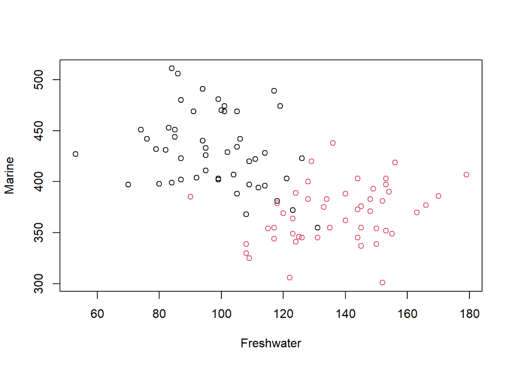

```r
plot(salmon[, -1], col = as.factor(salmon[, 1]))
```

We can so something a bit more fancy using the `ellipse` package.

```r
library(ellipse)
```

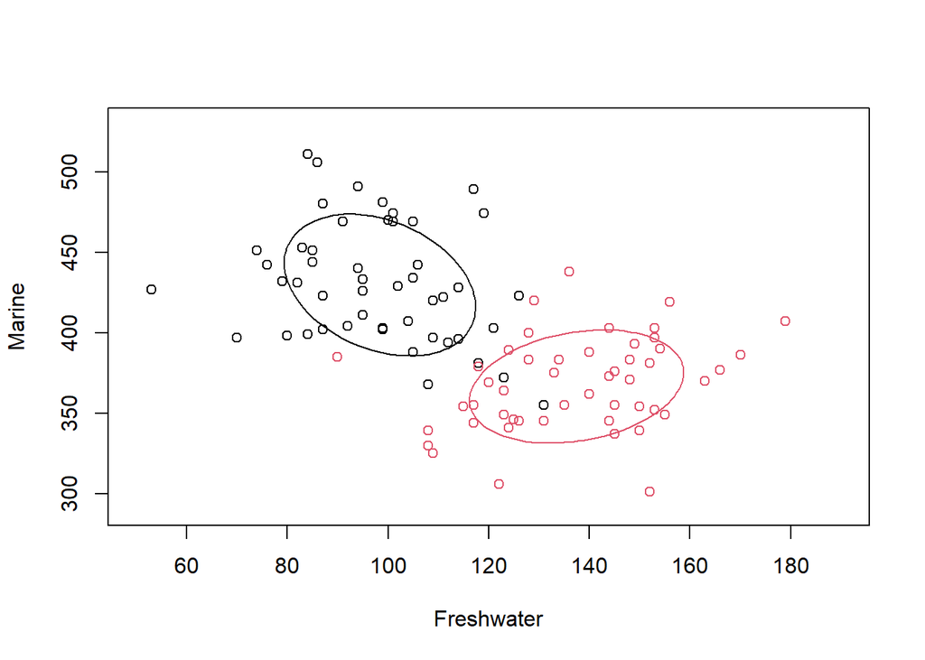

```r
plot(salmon[, c(2, 3)], col = as.factor(salmon[, 1]), xlim = c(50, 190), ylim = c(290, 530))
lines(ellipse(cov(salmon[c(1:50), c(2, 3)]), centre = colMeans(salmon[c(1:50), c(2, 3)]), level = c(0.5)))
lines(ellipse(cov(salmon[c(51:100), c(2, 3)]), centre = colMeans(salmon[c(51:100), c(2, 3)]), level = 0.5), col = 2)
```

### Splitting the data

Before we use LDA, we need to split the data into training and test sets. We don’t need a validation set because LDA uses probabilities to classify the data. It doesn’t have any hyperparameters to tune. So we don’t need a dataset for tuning the hyperparameters. We will only use the test set for evaluating the model.

The first 50 observations are from Alaska and the next 50 are from Canada.

```r
train <- salmon[c(1:40, 51:90), ]
test <- salmon[c(41:50, 91:100), ]
```

### Fitting the LDA model

```r
library(MASS)
lsol <- lda(train[, c(2, 3)], grouping = train[, 1])
print(lsol)
```

```
## Call:
## lda(train[, c(2, 3)], grouping = train[, 1])
##
## Prior probabilities of groups:
## Alaska Canada
##    0.5    0.5
##
## Group means:
##        Freshwater  Marine
## Alaska    100.550 422.275
## Canada    138.625 368.650
##
## Coefficients of linear discriminants:
##                    LD1
## Freshwater  0.04390178
## Marine     -0.01806237
```

We can access these information from the `lsol` object with `lsos$prior`, `lsol$means`, $\dots$ Note that the pooled covariance matrix is not provided, but we can calculate it using the `cov` function.

```r
alaska <- train[train == "Alaska", c(2, 3)]
canada <- train[train == "Canada", c(2, 3)]
n_alaska <- dim(alaska)[1]
n_canada <- dim(canada)[1]
pooled_cov <- ((n_alaska - 1) * cov(alaska) + (n_canada - 1) * cov(canada)) / (n_alaska + n_canada - 2)
pooled_cov
```

```
##            Freshwater     Marine
## Freshwater  322.22147  -15.24744
## Marine      -15.24744 1087.44968
```

### Classification

We can use the `predict` function to classify the test set. Lets try a salmon with Freshwater recording 120 and a Marine recording 380.

```r
predict(lsol, c(120, 380))
```

```
## $class
## [1] Canada
## Levels: Alaska Canada
##
## $posterior
##         Alaska    Canada
## [1,] 0.3132047 0.6867953
##
## $x
##            LD1
## [1,] 0.2973989
```

Lets evaluate the model using the test set.

```r
predict(lsol, test[, c(2, 3)])
```

```
## $class
##  [1] Alaska Alaska Alaska Alaska Alaska Alaska Alaska Alaska Alaska Alaska
## [11] Canada Canada Canada Canada Canada Canada Canada Canada Canada Canada
## Levels: Alaska Canada
##
## $posterior
##          Alaska       Canada
## 41  0.999934575 6.542453e-05
## 42  0.998909821 1.090179e-03
## 43  0.999641196 3.588039e-04
## 44  0.997267179 2.732821e-03
## 45  0.991071121 8.928879e-03
## 46  0.990434148 9.565852e-03
## 47  0.973525192 2.647481e-02
## 48  0.998445913 1.554087e-03
```

[output cut: 35 more lines]

How much uncertainty is there in relation to the classification of the datapoints?

```r
table(predict(lsol, test[, c(2, 3)])$class, test[, 1])
```

```
##
##          Alaska Canada
##   Alaska     10      0
##   Canada      0     10
```

The model correctly classified all 20 test observations. And it was very sure with the, with the exception of 92 and 100.

### Cross validation

We can easily perform leave-one-out cross validation by setting the `CV` parameter in the `lda` function to `TRUE`.

```r
lsol_cv <- lda(salmon[, c(2, 3)], grouping = salmon[, 1], CV = TRUE)
lsol_cv
```

```
## $class
##   [1] Canada Canada Alaska Alaska Alaska Alaska Alaska Alaska Alaska Alaska
##  [11] Alaska Canada Canada Alaska Alaska Alaska Alaska Alaska Alaska Alaska
##  [21] Alaska Alaska Alaska Alaska Alaska Alaska Alaska Alaska Alaska Canada
##  [31] Alaska Canada Alaska Alaska Alaska Alaska Alaska Alaska Alaska Alaska
##  [41] Alaska Alaska Alaska Alaska Alaska Alaska Alaska Alaska Alaska Alaska
##  [51] Canada Canada Canada Canada Canada Canada Canada Canada Canada Canada
##  [61] Canada Canada Canada Canada Canada Canada Canada Canada Canada Canada
##  [71] Alaska Canada Canada Canada Canada Canada Canada Canada Canada Canada
##  [81] Canada Canada Canada Canada Canada Canada Canada Canada Canada Canada
##  [91] Canada Canada Canada Canada Canada Canada Canada Canada Canada Canada
## Levels: Alaska Canada
##
## $posterior
##           Alaska       Canada
```

[output cut: 103 more lines]

We can see that output returned by `lsol_cv` includes a list of how data points were classified when they were the only point left out. Additionally, a matrix of group membership probability is returned. The class assigned to each data point is stored in `lsol_cv$class`. We can use this to count how many points were missclassified.

```r
table(lsol_cv$class, salmon[, 1])
```

```
##
##          Alaska Canada
##   Alaska     44      1
##   Canada      6     49
```

We can see that the model misclassified 7 observations. It put 1 Canadian salmon to Alaska, and 6 Alaskan salmon to Canada.

### Visializing the results

We will plot the data colored with the true class, but the points will be marked with the class that the LDA model predicted.

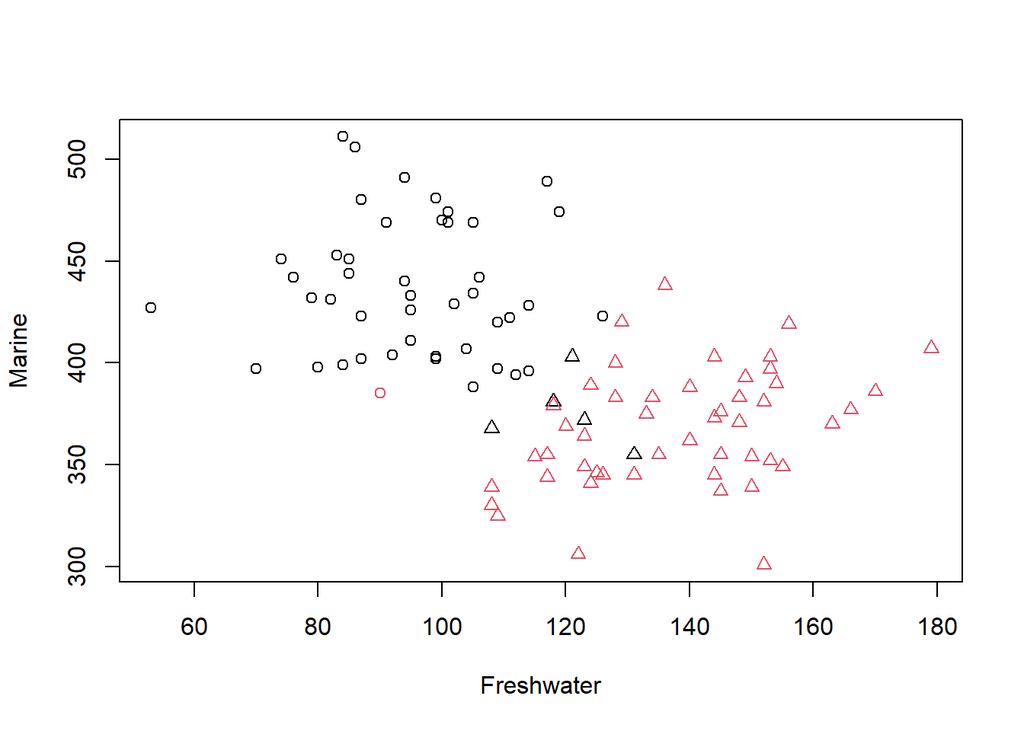

```r
plot(salmon[, c(2, 3)], col = as.factor(salmon[, 1]), pch = as.numeric(lsol_cv$class))
```

## Quadratic Discriminant Analysis (QDA)

QDA assumes that each cluster has a different covariance matrix.

```r
qsol <- qda(train[, c(2, 3)], grouping = train[, 1])
predict(qsol, test[, c(2, 3)])
```

```
## $class
##  [1] Alaska Alaska Alaska Alaska Alaska Alaska Alaska Alaska Alaska Alaska
## [11] Canada Canada Canada Canada Canada Canada Canada Canada Canada Canada
## Levels: Alaska Canada
##
## $posterior
##          Alaska       Canada
## 41  0.999999603 3.973313e-07
## 42  0.999934364 6.563641e-05
## 43  0.999975258 2.474169e-05
## 44  0.999739798 2.602019e-04
## 45  0.992748801 7.251199e-03
## 46  0.997730481 2.269519e-03
## 47  0.985325240 1.467476e-02
## 48  0.999895544 1.044557e-04
## 49  0.999982257 1.774293e-05
## 50  0.999987507 1.249314e-05
## 91  0.112831650 8.871684e-01
## 92  0.237765000 7.622350e-01
## 93  0.111230243 8.887698e-01
## 94  0.030850466 9.691495e-01
## 95  0.074449894 9.255501e-01
## 96  0.008231741 9.917683e-01
## 97  0.076453258 9.235467e-01
## 98  0.085706823 9.142932e-01
## 99  0.007297430 9.927026e-01
## 100 0.182480379 8.175196e-01
```

We will again perform cross validation.

```r
qsol_cv <- qda(salmon[, c(2, 3)], grouping = salmon[, 1], CV = TRUE)
table(qsol_cv$class, salmon[, 1])
```

```
##
##          Alaska Canada
##   Alaska     45      3
##   Canada      5     47
```

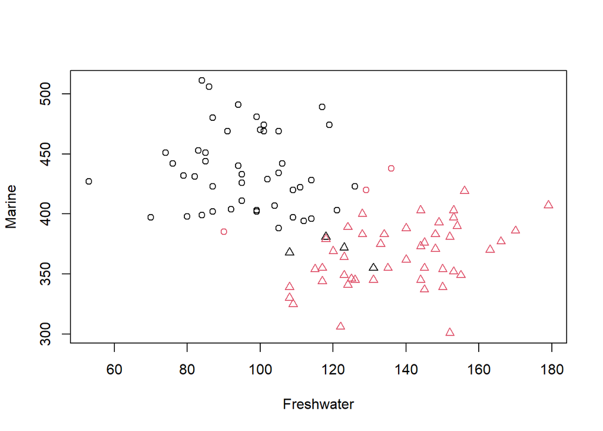

```r
plot(salmon[, c(2, 3)], col = as.factor(salmon[, 1]), pch = as.numeric(qsol_cv$class))
```